# Risk Factor Analysis

## Outcome Variable

**Outcome Variable:** ever_stunted

## Predictor Variables

**Intervention Variable:** impsan

**Adjustment Set:**

- arm
- W_mage
- meducyrs
- feducyrs
- hhwealth_quart
- hfoodsec
- W_mhtcm
- W_mwtkg
- W_mbmi
- W_nrooms
- W_nchldlt5
- W_parity
- impfloor
- safeh20
- delta_W_mage
- delta_meducyrs
- delta_feducyrs
- delta_hhwealth_quart
- delta_hfoodsec
- delta_W_mhtcm
- delta_W_mwtkg
- delta_W_mbmi
- delta_W_nrooms
- delta_W_nchldlt5
- delta_W_parity
- delta_impfloor
- delta_safeh20

## Stratifying Variables

The analysis was stratified on these variable(s):

- agecat
- studyid
- country

## Data Summary

| agecat | studyid | country | impsan | ever_stunted | n_cell | n |
| --- | --- | --- | --- | --- | --- | --- |
| 0-24 months (no birth st.) | ki0047075b-MAL-ED | BANGLADESH | 1 | 0 | 82 | 203 |
| 0-24 months (no birth st.) | ki0047075b-MAL-ED | BANGLADESH | 1 | 1 | 88 | 203 |
| 0-24 months (no birth st.) | ki0047075b-MAL-ED | BANGLADESH | 0 | 0 | 11 | 203 |
| 0-24 months (no birth st.) | ki0047075b-MAL-ED | BANGLADESH | 0 | 1 | 22 | 203 |
| 0-24 months (no birth st.) | ki0047075b-MAL-ED | BRAZIL | 1 | 0 | 151 | 185 |
| 0-24 months (no birth st.) | ki0047075b-MAL-ED | BRAZIL | 1 | 1 | 30 | 185 |
| 0-24 months (no birth st.) | ki0047075b-MAL-ED | BRAZIL | 0 | 0 | 3 | 185 |
| 0-24 months (no birth st.) | ki0047075b-MAL-ED | BRAZIL | 0 | 1 | 1 | 185 |
| 0-24 months (no birth st.) | ki0047075b-MAL-ED | INDIA | 1 | 0 | 44 | 196 |
| 0-24 months (no birth st.) | ki0047075b-MAL-ED | INDIA | 1 | 1 | 44 | 196 |
| 0-24 months (no birth st.) | ki0047075b-MAL-ED | INDIA | 0 | 0 | 45 | 196 |
| 0-24 months (no birth st.) | ki0047075b-MAL-ED | INDIA | 0 | 1 | 63 | 196 |
| 0-24 months (no birth st.) | ki0047075b-MAL-ED | NEPAL | 1 | 0 | 153 | 208 |
| 0-24 months (no birth st.) | ki0047075b-MAL-ED | NEPAL | 1 | 1 | 54 | 208 |
| 0-24 months (no birth st.) | ki0047075b-MAL-ED | NEPAL | 0 | 0 | 1 | 208 |
| 0-24 months (no birth st.) | ki0047075b-MAL-ED | NEPAL | 0 | 1 | 0 | 208 |
| 0-24 months (no birth st.) | ki0047075b-MAL-ED | PERU | 1 | 0 | 26 | 231 |
| 0-24 months (no birth st.) | ki0047075b-MAL-ED | PERU | 1 | 1 | 31 | 231 |
| 0-24 months (no birth st.) | ki0047075b-MAL-ED | PERU | 0 | 0 | 63 | 231 |
| 0-24 months (no birth st.) | ki0047075b-MAL-ED | PERU | 0 | 1 | 111 | 231 |
| 0-24 months (no birth st.) | ki0047075b-MAL-ED | SOUTH AFRICA | 1 | 0 | 3 | 225 |
| 0-24 months (no birth st.) | ki0047075b-MAL-ED | SOUTH AFRICA | 1 | 1 | 1 | 225 |
| 0-24 months (no birth st.) | ki0047075b-MAL-ED | SOUTH AFRICA | 0 | 0 | 93 | 225 |
| 0-24 months (no birth st.) | ki0047075b-MAL-ED | SOUTH AFRICA | 0 | 1 | 128 | 225 |
| 0-24 months (no birth st.) | ki0047075b-MAL-ED | TANZANIA, UNITED REPUBLIC OF | 1 | 0 | 0 | 202 |
| 0-24 months (no birth st.) | ki0047075b-MAL-ED | TANZANIA, UNITED REPUBLIC OF | 1 | 1 | 0 | 202 |
| 0-24 months (no birth st.) | ki0047075b-MAL-ED | TANZANIA, UNITED REPUBLIC OF | 0 | 0 | 30 | 202 |
| 0-24 months (no birth st.) | ki0047075b-MAL-ED | TANZANIA, UNITED REPUBLIC OF | 0 | 1 | 172 | 202 |
| 0-24 months (no birth st.) | ki1017093-NIH-Birth | BANGLADESH | 1 | 0 | 92 | 530 |
| 0-24 months (no birth st.) | ki1017093-NIH-Birth | BANGLADESH | 1 | 1 | 111 | 530 |

[output cut: 174 more lines]

The following strata were considered:

- agecat: 0-24 months (no birth st.), studyid: ki0047075b-MAL-ED, country: BANGLADESH
- agecat: 0-24 months (no birth st.), studyid: ki0047075b-MAL-ED, country: BRAZIL
- agecat: 0-24 months (no birth st.), studyid: ki0047075b-MAL-ED, country: INDIA
- agecat: 0-24 months (no birth st.), studyid: ki0047075b-MAL-ED, country: NEPAL
- agecat: 0-24 months (no birth st.), studyid: ki0047075b-MAL-ED, country: PERU
- agecat: 0-24 months (no birth st.), studyid: ki0047075b-MAL-ED, country: SOUTH AFRICA
- agecat: 0-24 months (no birth st.), studyid: ki0047075b-MAL-ED, country: TANZANIA, UNITED REPUBLIC OF
- agecat: 0-24 months (no birth st.), studyid: ki1017093-NIH-Birth, country: BANGLADESH
- agecat: 0-24 months (no birth st.), studyid: ki1017093b-PROVIDE, country: BANGLADESH
- agecat: 0-24 months (no birth st.), studyid: ki1017093c-NIH-Crypto, country: BANGLADESH
- agecat: 0-24 months (no birth st.), studyid: ki1114097-CONTENT, country: PERU
- agecat: 0-24 months (no birth st.), studyid: ki1135781-COHORTS, country: GUATEMALA
- agecat: 0-24 months (no birth st.), studyid: ki1135781-COHORTS, country: INDIA
- agecat: 0-24 months (no birth st.), studyid: ki1135781-COHORTS, country: PHILIPPINES
- agecat: 0-24 months (no birth st.), studyid: ki1148112-LCNI-5, country: MALAWI
- agecat: 0-24 months (no birth st.), studyid: kiGH5241-JiVitA-3, country: BANGLADESH
- agecat: 0-24 months (no birth st.), studyid: kiGH5241-JiVitA-4, country: BANGLADESH
- agecat: 0-6 months (no birth st.), studyid: ki0047075b-MAL-ED, country: BANGLADESH
- agecat: 0-6 months (no birth st.), studyid: ki0047075b-MAL-ED, country: BRAZIL
- agecat: 0-6 months (no birth st.), studyid: ki0047075b-MAL-ED, country: INDIA
- agecat: 0-6 months (no birth st.), studyid: ki0047075b-MAL-ED, country: NEPAL
- agecat: 0-6 months (no birth st.), studyid: ki0047075b-MAL-ED, country: PERU
- agecat: 0-6 months (no birth st.), studyid: ki0047075b-MAL-ED, country: SOUTH AFRICA
- agecat: 0-6 months (no birth st.), studyid: ki0047075b-MAL-ED, country: TANZANIA, UNITED REPUBLIC OF
- agecat: 0-6 months (no birth st.), studyid: ki1017093-NIH-Birth, country: BANGLADESH
- agecat: 0-6 months (no birth st.), studyid: ki1017093b-PROVIDE, country: BANGLADESH
- agecat: 0-6 months (no birth st.), studyid: ki1017093c-NIH-Crypto, country: BANGLADESH
- agecat: 0-6 months (no birth st.), studyid: ki1114097-CONTENT, country: PERU
- agecat: 0-6 months (no birth st.), studyid: ki1135781-COHORTS, country: GUATEMALA
- agecat: 0-6 months (no birth st.), studyid: ki1135781-COHORTS, country: INDIA
- agecat: 0-6 months (no birth st.), studyid: ki1135781-COHORTS, country: PHILIPPINES
- agecat: 0-6 months (no birth st.), studyid: ki1148112-LCNI-5, country: MALAWI
- agecat: 0-6 months (no birth st.), studyid: kiGH5241-JiVitA-3, country: BANGLADESH
- agecat: 0-6 months (no birth st.), studyid: kiGH5241-JiVitA-4, country: BANGLADESH
- agecat: 6-24 months, studyid: ki0047075b-MAL-ED, country: BANGLADESH
- agecat: 6-24 months, studyid: ki0047075b-MAL-ED, country: BRAZIL
- agecat: 6-24 months, studyid: ki0047075b-MAL-ED, country: INDIA
- agecat: 6-24 months, studyid: ki0047075b-MAL-ED, country: NEPAL
- agecat: 6-24 months, studyid: ki0047075b-MAL-ED, country: PERU
- agecat: 6-24 months, studyid: ki0047075b-MAL-ED, country: SOUTH AFRICA
- agecat: 6-24 months, studyid: ki0047075b-MAL-ED, country: TANZANIA, UNITED REPUBLIC OF
- agecat: 6-24 months, studyid: ki1017093-NIH-Birth, country: BANGLADESH
- agecat: 6-24 months, studyid: ki1017093b-PROVIDE, country: BANGLADESH
- agecat: 6-24 months, studyid: ki1017093c-NIH-Crypto, country: BANGLADESH
- agecat: 6-24 months, studyid: ki1114097-CONTENT, country: PERU
- agecat: 6-24 months, studyid: ki1135781-COHORTS, country: GUATEMALA
- agecat: 6-24 months, studyid: ki1135781-COHORTS, country: INDIA
- agecat: 6-24 months, studyid: ki1135781-COHORTS, country: PHILIPPINES
- agecat: 6-24 months, studyid: ki1148112-LCNI-5, country: MALAWI
- agecat: 6-24 months, studyid: kiGH5241-JiVitA-3, country: BANGLADESH
- agecat: 6-24 months, studyid: kiGH5241-JiVitA-4, country: BANGLADESH

### Dropped Strata

Some strata were dropped due to rare outcomes:

- agecat: 0-24 months (no birth st.), studyid: ki0047075b-MAL-ED, country: BRAZIL
- agecat: 0-24 months (no birth st.), studyid: ki0047075b-MAL-ED, country: NEPAL
- agecat: 0-24 months (no birth st.), studyid: ki0047075b-MAL-ED, country: SOUTH AFRICA
- agecat: 0-24 months (no birth st.), studyid: ki0047075b-MAL-ED, country: TANZANIA, UNITED REPUBLIC OF
- agecat: 0-24 months (no birth st.), studyid: ki1017093b-PROVIDE, country: BANGLADESH
- agecat: 0-24 months (no birth st.), studyid: ki1148112-LCNI-5, country: MALAWI
- agecat: 0-6 months (no birth st.), studyid: ki0047075b-MAL-ED, country: BRAZIL
- agecat: 0-6 months (no birth st.), studyid: ki0047075b-MAL-ED, country: NEPAL
- agecat: 0-6 months (no birth st.), studyid: ki0047075b-MAL-ED, country: SOUTH AFRICA
- agecat: 0-6 months (no birth st.), studyid: ki0047075b-MAL-ED, country: TANZANIA, UNITED REPUBLIC OF
- agecat: 0-6 months (no birth st.), studyid: ki1017093b-PROVIDE, country: BANGLADESH
- agecat: 0-6 months (no birth st.), studyid: ki1148112-LCNI-5, country: MALAWI
- agecat: 6-24 months, studyid: ki0047075b-MAL-ED, country: BRAZIL
- agecat: 6-24 months, studyid: ki0047075b-MAL-ED, country: NEPAL
- agecat: 6-24 months, studyid: ki0047075b-MAL-ED, country: SOUTH AFRICA
- agecat: 6-24 months, studyid: ki0047075b-MAL-ED, country: TANZANIA, UNITED REPUBLIC OF
- agecat: 6-24 months, studyid: ki1017093b-PROVIDE, country: BANGLADESH
- agecat: 6-24 months, studyid: ki1114097-CONTENT, country: PERU
- agecat: 6-24 months, studyid: ki1148112-LCNI-5, country: MALAWI

## Methods Detail

We’re interested in the causal parameters $E[Y_a]$ for all values of $a \in \mathcal{A}$. These parameters represent the mean outcome if, possibly contrary to fact, we intervened to set all units to have $A=a$. Under the randomization and positivity assumptions, these are identified by the statistical parameters $\psi_a=E_W[E_{Y|A,W}(Y|A=a,W)]$. In addition, we’re interested in the mean of $Y$, $E[Y]$ under no intervention (the observed mean). We will estimate these parameters by using SuperLearner to fit the relevant likelihood factors – $E_{Y|A,W}(Y|A=a,W)$ and $p(A=a|W)$, and then updating our likelihood fit using a joint TMLE.

For unadjusted analyses ($W=\{\}$), initial likelihoods were estimated using Lrnr_glm to estimate the simple $E(Y|A)$ and Lrnr_mean to estimate $p(A)$. For adjusted analyses, a small library containing Lrnr_glmnet, Lrnr_xgboost, and Lrnr_mean was used.

Having estimated these parameters, we will then use the delta method to estimate relative risks and attributable risks relative to a prespecified baseline level of $A$.

# Results Detail

## Results Plots

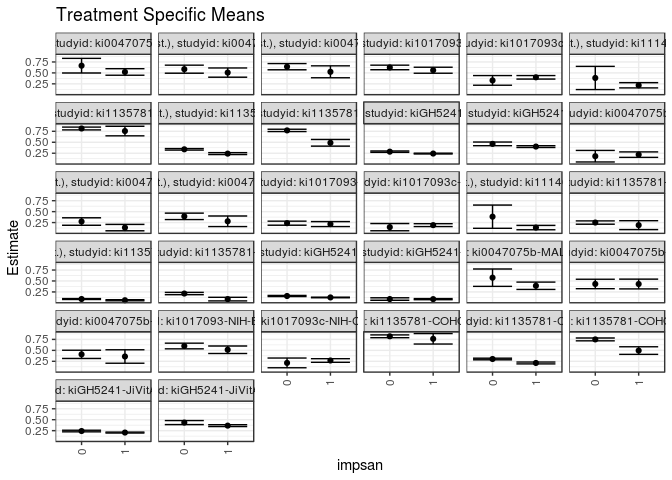

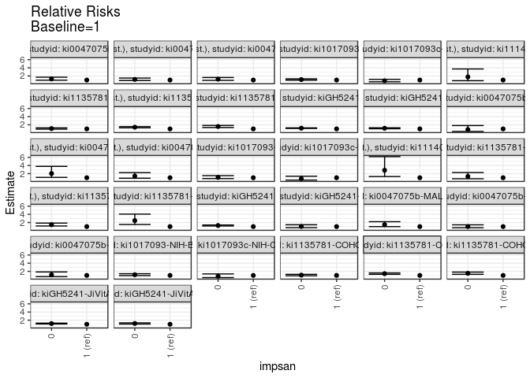

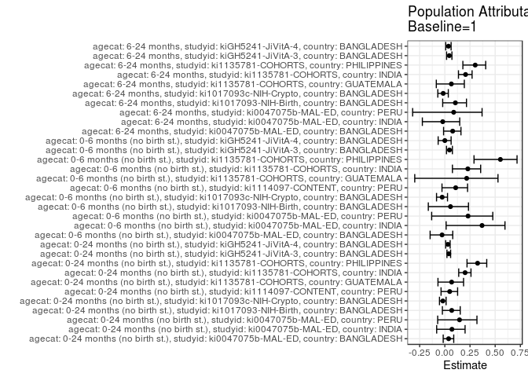

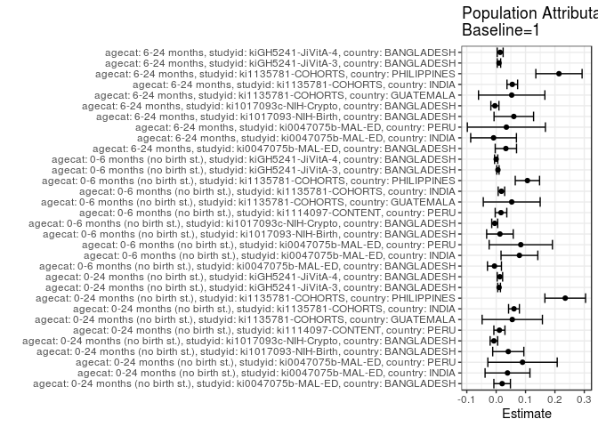

## Results Table

### Parameter: TSM

| agecat | studyid | country | intervention_level | baseline_level | estimate | ci_lower | ci_upper |
| --- | --- | --- | --- | --- | --- | --- | --- |
| 0-24 months (no birth st.) | ki0047075b-MAL-ED | BANGLADESH | 1 | NA | 0.5215194 | 0.4468248 | 0.5962139 |
| 0-24 months (no birth st.) | ki0047075b-MAL-ED | BANGLADESH | 0 | NA | 0.6649606 | 0.4979022 | 0.8320191 |
| 0-24 months (no birth st.) | ki0047075b-MAL-ED | INDIA | 1 | NA | 0.5073274 | 0.4020030 | 0.6126518 |
| 0-24 months (no birth st.) | ki0047075b-MAL-ED | INDIA | 0 | NA | 0.5850338 | 0.4932901 | 0.6767776 |
| 0-24 months (no birth st.) | ki0047075b-MAL-ED | PERU | 1 | NA | 0.5249978 | 0.3887898 | 0.6612058 |
| 0-24 months (no birth st.) | ki0047075b-MAL-ED | PERU | 0 | NA | 0.6422233 | 0.5708297 | 0.7136169 |
| 0-24 months (no birth st.) | ki1017093-NIH-Birth | BANGLADESH | 1 | NA | 0.5606864 | 0.4921159 | 0.6292569 |
| 0-24 months (no birth st.) | ki1017093-NIH-Birth | BANGLADESH | 0 | NA | 0.6246327 | 0.5726655 | 0.6766000 |
| 0-24 months (no birth st.) | ki1017093c-NIH-Crypto | BANGLADESH | 1 | NA | 0.3996075 | 0.3594736 | 0.4397415 |
| 0-24 months (no birth st.) | ki1017093c-NIH-Crypto | BANGLADESH | 0 | NA | 0.3287787 | 0.2180326 | 0.4395248 |
| 0-24 months (no birth st.) | ki1114097-CONTENT | PERU | 1 | NA | 0.2173913 | 0.1576413 | 0.2771413 |
| 0-24 months (no birth st.) | ki1114097-CONTENT | PERU | 0 | NA | 0.3846154 | 0.1194797 | 0.6497510 |
| 0-24 months (no birth st.) | ki1135781-COHORTS | GUATEMALA | 1 | NA | 0.7561917 | 0.6471121 | 0.8652712 |
| 0-24 months (no birth st.) | ki1135781-COHORTS | GUATEMALA | 0 | NA | 0.8143851 | 0.7824696 | 0.8463006 |
| 0-24 months (no birth st.) | ki1135781-COHORTS | INDIA | 1 | NA | 0.2407348 | 0.2191767 | 0.2622928 |
| 0-24 months (no birth st.) | ki1135781-COHORTS | INDIA | 0 | NA | 0.3390412 | 0.3215646 | 0.3565178 |
| 0-24 months (no birth st.) | ki1135781-COHORTS | PHILIPPINES | 1 | NA | 0.4876984 | 0.4116113 | 0.5637855 |
| 0-24 months (no birth st.) | ki1135781-COHORTS | PHILIPPINES | 0 | NA | 0.7711551 | 0.7442588 | 0.7980515 |
| 0-24 months (no birth st.) | kiGH5241-JiVitA-3 | BANGLADESH | 1 | NA | 0.2424306 | 0.2335255 | 0.2513356 |
| 0-24 months (no birth st.) | kiGH5241-JiVitA-3 | BANGLADESH | 0 | NA | 0.2853441 | 0.2700494 | 0.3006388 |
| 0-24 months (no birth st.) | kiGH5241-JiVitA-4 | BANGLADESH | 1 | NA | 0.4017126 | 0.3813991 | 0.4220261 |
| 0-24 months (no birth st.) | kiGH5241-JiVitA-4 | BANGLADESH | 0 | NA | 0.4632519 | 0.4212169 | 0.5052869 |
| 0-6 months (no birth st.) | ki0047075b-MAL-ED | BANGLADESH | 1 | NA | 0.2176471 | 0.1554638 | 0.2798304 |
| 0-6 months (no birth st.) | ki0047075b-MAL-ED | BANGLADESH | 0 | NA | 0.1818182 | 0.0498993 | 0.3137371 |
| 0-6 months (no birth st.) | ki0047075b-MAL-ED | INDIA | 1 | NA | 0.1351006 | 0.0621209 | 0.2080803 |
| 0-6 months (no birth st.) | ki0047075b-MAL-ED | INDIA | 0 | NA | 0.2740311 | 0.1887798 | 0.3592824 |
| 0-6 months (no birth st.) | ki0047075b-MAL-ED | PERU | 1 | NA | 0.2798237 | 0.1592873 | 0.4003602 |
| 0-6 months (no birth st.) | ki0047075b-MAL-ED | PERU | 0 | NA | 0.3922844 | 0.3188178 | 0.4657509 |
| 0-6 months (no birth st.) | ki1017093-NIH-Birth | BANGLADESH | 1 | NA | 0.2154645 | 0.1588779 | 0.2720510 |
| 0-6 months (no birth st.) | ki1017093-NIH-Birth | BANGLADESH | 0 | NA | 0.2361807 | 0.1902486 | 0.2821129 |
| 0-6 months (no birth st.) | ki1017093c-NIH-Crypto | BANGLADESH | 1 | NA | 0.1915536 | 0.1592252 | 0.2238821 |
| 0-6 months (no birth st.) | ki1017093c-NIH-Crypto | BANGLADESH | 0 | NA | 0.1457364 | 0.0632926 | 0.2281802 |
| 0-6 months (no birth st.) | ki1114097-CONTENT | PERU | 1 | NA | 0.1358696 | 0.0862338 | 0.1855054 |
| 0-6 months (no birth st.) | ki1114097-CONTENT | PERU | 0 | NA | 0.3846154 | 0.1194797 | 0.6497510 |
| 0-6 months (no birth st.) | ki1135781-COHORTS | GUATEMALA | 1 | NA | 0.1912531 | 0.0897325 | 0.2927736 |
| 0-6 months (no birth st.) | ki1135781-COHORTS | GUATEMALA | 0 | NA | 0.2507022 | 0.2129171 | 0.2884872 |
| 0-6 months (no birth st.) | ki1135781-COHORTS | INDIA | 1 | NA | 0.0604709 | 0.0479641 | 0.0729778 |
| 0-6 months (no birth st.) | ki1135781-COHORTS | INDIA | 0 | NA | 0.0880759 | 0.0776340 | 0.0985178 |
| 0-6 months (no birth st.) | ki1135781-COHORTS | PHILIPPINES | 1 | NA | 0.0864263 | 0.0450110 | 0.1278415 |
| 0-6 months (no birth st.) | ki1135781-COHORTS | PHILIPPINES | 0 | NA | 0.2133179 | 0.1870921 | 0.2395438 |
| 0-6 months (no birth st.) | kiGH5241-JiVitA-3 | BANGLADESH | 1 | NA | 0.1243455 | 0.1177601 | 0.1309309 |
| 0-6 months (no birth st.) | kiGH5241-JiVitA-3 | BANGLADESH | 0 | NA | 0.1569945 | 0.1442237 | 0.1697654 |
| 0-6 months (no birth st.) | kiGH5241-JiVitA-4 | BANGLADESH | 1 | NA | 0.0854431 | 0.0727906 | 0.0980955 |
| 0-6 months (no birth st.) | kiGH5241-JiVitA-4 | BANGLADESH | 0 | NA | 0.0877934 | 0.0596591 | 0.1159276 |
| 6-24 months | ki0047075b-MAL-ED | BANGLADESH | 1 | NA | 0.3909999 | 0.3073576 | 0.4746422 |
| 6-24 months | ki0047075b-MAL-ED | BANGLADESH | 0 | NA | 0.5755681 | 0.3774388 | 0.7736974 |
| 6-24 months | ki0047075b-MAL-ED | INDIA | 1 | NA | 0.4309277 | 0.3193962 | 0.5424593 |
| 6-24 months | ki0047075b-MAL-ED | INDIA | 0 | NA | 0.4322306 | 0.3241045 | 0.5403567 |
| 6-24 months | ki0047075b-MAL-ED | PERU | 1 | NA | 0.3598057 | 0.2059277 | 0.5136837 |
| 6-24 months | ki0047075b-MAL-ED | PERU | 0 | NA | 0.4085150 | 0.3144194 | 0.5026106 |
| 6-24 months | ki1017093-NIH-Birth | BANGLADESH | 1 | NA | 0.5138395 | 0.4281633 | 0.5995157 |
| 6-24 months | ki1017093-NIH-Birth | BANGLADESH | 0 | NA | 0.5992071 | 0.5342033 | 0.6642109 |
| 6-24 months | ki1017093c-NIH-Crypto | BANGLADESH | 1 | NA | 0.2682970 | 0.2268511 | 0.3097429 |
| 6-24 months | ki1017093c-NIH-Crypto | BANGLADESH | 0 | NA | 0.2133312 | 0.1024898 | 0.3241726 |
| 6-24 months | ki1135781-COHORTS | GUATEMALA | 1 | NA | 0.7634190 | 0.6437938 | 0.8830442 |
| 6-24 months | ki1135781-COHORTS | GUATEMALA | 0 | NA | 0.8206815 | 0.7889974 | 0.8523657 |
| 6-24 months | ki1135781-COHORTS | INDIA | 1 | NA | 0.2117715 | 0.1904544 | 0.2330886 |
| 6-24 months | ki1135781-COHORTS | INDIA | 0 | NA | 0.3025578 | 0.2842435 | 0.3208720 |
| 6-24 months | ki1135781-COHORTS | PHILIPPINES | 1 | NA | 0.4948405 | 0.4081986 | 0.5814824 |
| 6-24 months | ki1135781-COHORTS | PHILIPPINES | 0 | NA | 0.7498780 | 0.7177516 | 0.7820044 |
| 6-24 months | kiGH5241-JiVitA-3 | BANGLADESH | 1 | NA | 0.2066286 | 0.1957168 | 0.2175403 |
| 6-24 months | kiGH5241-JiVitA-3 | BANGLADESH | 0 | NA | 0.2411774 | 0.2225589 | 0.2597960 |
| 6-24 months | kiGH5241-JiVitA-4 | BANGLADESH | 1 | NA | 0.3648036 | 0.3439309 | 0.3856764 |
| 6-24 months | kiGH5241-JiVitA-4 | BANGLADESH | 0 | NA | 0.4346648 | 0.3885101 | 0.4808195 |

### Parameter: E(Y)

| agecat | studyid | country | intervention_level | baseline_level | estimate | ci_lower | ci_upper |
| --- | --- | --- | --- | --- | --- | --- | --- |
| 0-24 months (no birth st.) | ki0047075b-MAL-ED | BANGLADESH | NA | NA | 0.5418719 | 0.4731628 | 0.6105810 |
| 0-24 months (no birth st.) | ki0047075b-MAL-ED | INDIA | NA | NA | 0.5459184 | 0.4760370 | 0.6157998 |
| 0-24 months (no birth st.) | ki0047075b-MAL-ED | PERU | NA | NA | 0.6147186 | 0.5518243 | 0.6776129 |
| 0-24 months (no birth st.) | ki1017093-NIH-Birth | BANGLADESH | NA | NA | 0.6018868 | 0.5601729 | 0.6436007 |
| 0-24 months (no birth st.) | ki1017093c-NIH-Crypto | BANGLADESH | NA | NA | 0.3919129 | 0.3541506 | 0.4296752 |
| 0-24 months (no birth st.) | ki1114097-CONTENT | PERU | NA | NA | 0.2284264 | 0.1696529 | 0.2871999 |
| 0-24 months (no birth st.) | ki1135781-COHORTS | GUATEMALA | NA | NA | 0.8110236 | 0.7805500 | 0.8414972 |
| 0-24 months (no birth st.) | ki1135781-COHORTS | INDIA | NA | NA | 0.3013786 | 0.2882798 | 0.3144773 |
| 0-24 months (no birth st.) | ki1135781-COHORTS | PHILIPPINES | NA | NA | 0.7228700 | 0.6965868 | 0.7491531 |
| 0-24 months (no birth st.) | kiGH5241-JiVitA-3 | BANGLADESH | NA | NA | 0.2523838 | 0.2446469 | 0.2601207 |
| 0-24 months (no birth st.) | kiGH5241-JiVitA-4 | BANGLADESH | NA | NA | 0.4144516 | 0.3962595 | 0.4326437 |
| 0-6 months (no birth st.) | ki0047075b-MAL-ED | BANGLADESH | NA | NA | 0.2118227 | 0.1554757 | 0.2681696 |
| 0-6 months (no birth st.) | ki0047075b-MAL-ED | INDIA | NA | NA | 0.2142857 | 0.1566940 | 0.2718774 |
| 0-6 months (no birth st.) | ki0047075b-MAL-ED | PERU | NA | NA | 0.3636364 | 0.3014678 | 0.4258049 |
| 0-6 months (no birth st.) | ki1017093-NIH-Birth | BANGLADESH | NA | NA | 0.2283019 | 0.1925336 | 0.2640702 |
| 0-6 months (no birth st.) | ki1017093c-NIH-Crypto | BANGLADESH | NA | NA | 0.1866252 | 0.1564874 | 0.2167630 |
| 0-6 months (no birth st.) | ki1114097-CONTENT | PERU | NA | NA | 0.1522843 | 0.1019837 | 0.2025848 |
| 0-6 months (no birth st.) | ki1135781-COHORTS | GUATEMALA | NA | NA | 0.2442478 | 0.2087898 | 0.2797057 |
| 0-6 months (no birth st.) | ki1135781-COHORTS | INDIA | NA | NA | 0.0783541 | 0.0705612 | 0.0861470 |
| 0-6 months (no birth st.) | ki1135781-COHORTS | PHILIPPINES | NA | NA | 0.1928251 | 0.1696580 | 0.2159922 |
| 0-6 months (no birth st.) | kiGH5241-JiVitA-3 | BANGLADESH | NA | NA | 0.1303730 | 0.1247937 | 0.1359524 |
| 0-6 months (no birth st.) | kiGH5241-JiVitA-4 | BANGLADESH | NA | NA | 0.0854560 | 0.0740923 | 0.0968198 |
| 6-24 months | ki0047075b-MAL-ED | BANGLADESH | NA | NA | 0.4240506 | 0.3467471 | 0.5013542 |
| 6-24 months | ki0047075b-MAL-ED | INDIA | NA | NA | 0.4220779 | 0.3438191 | 0.5003367 |
| 6-24 months | ki0047075b-MAL-ED | PERU | NA | NA | 0.3945578 | 0.3152779 | 0.4738378 |
| 6-24 months | ki1017093-NIH-Birth | BANGLADESH | NA | NA | 0.5739130 | 0.5216565 | 0.6261696 |
| 6-24 months | ki1017093c-NIH-Crypto | BANGLADESH | NA | NA | 0.2640000 | 0.2253243 | 0.3026757 |
| 6-24 months | ki1135781-COHORTS | GUATEMALA | NA | NA | 0.8162939 | 0.7859345 | 0.8466533 |
| 6-24 months | ki1135781-COHORTS | INDIA | NA | NA | 0.2666991 | 0.2531888 | 0.2802093 |
| 6-24 months | ki1135781-COHORTS | PHILIPPINES | NA | NA | 0.7086331 | 0.6777759 | 0.7394903 |
| 6-24 months | kiGH5241-JiVitA-3 | BANGLADESH | NA | NA | 0.2162136 | 0.2068317 | 0.2255956 |
| 6-24 months | kiGH5241-JiVitA-4 | BANGLADESH | NA | NA | 0.3784303 | 0.3598372 | 0.3970234 |

### Parameter: RR

| agecat | studyid | country | intervention_level | baseline_level | estimate | ci_lower | ci_upper |
| --- | --- | --- | --- | --- | --- | --- | --- |
| 0-24 months (no birth st.) | ki0047075b-MAL-ED | BANGLADESH | 1 | 1 | 1.0000000 | 1.0000000 | 1.000000 |
| 0-24 months (no birth st.) | ki0047075b-MAL-ED | BANGLADESH | 0 | 1 | 1.2750450 | 0.9604879 | 1.692619 |
| 0-24 months (no birth st.) | ki0047075b-MAL-ED | INDIA | 1 | 1 | 1.0000000 | 1.0000000 | 1.000000 |
| 0-24 months (no birth st.) | ki0047075b-MAL-ED | INDIA | 0 | 1 | 1.1531683 | 0.8911003 | 1.492309 |
| 0-24 months (no birth st.) | ki0047075b-MAL-ED | PERU | 1 | 1 | 1.0000000 | 1.0000000 | 1.000000 |
| 0-24 months (no birth st.) | ki0047075b-MAL-ED | PERU | 0 | 1 | 1.2232876 | 0.9218674 | 1.623262 |
| 0-24 months (no birth st.) | ki1017093-NIH-Birth | BANGLADESH | 1 | 1 | 1.0000000 | 1.0000000 | 1.000000 |
| 0-24 months (no birth st.) | ki1017093-NIH-Birth | BANGLADESH | 0 | 1 | 1.1140501 | 0.9627848 | 1.289081 |
| 0-24 months (no birth st.) | ki1017093c-NIH-Crypto | BANGLADESH | 1 | 1 | 1.0000000 | 1.0000000 | 1.000000 |
| 0-24 months (no birth st.) | ki1017093c-NIH-Crypto | BANGLADESH | 0 | 1 | 0.8227539 | 0.5800217 | 1.167067 |
| 0-24 months (no birth st.) | ki1114097-CONTENT | PERU | 1 | 1 | 1.0000000 | 1.0000000 | 1.000000 |
| 0-24 months (no birth st.) | ki1114097-CONTENT | PERU | 0 | 1 | 1.7692308 | 0.8423327 | 3.716082 |
| 0-24 months (no birth st.) | ki1135781-COHORTS | GUATEMALA | 1 | 1 | 1.0000000 | 1.0000000 | 1.000000 |
| 0-24 months (no birth st.) | ki1135781-COHORTS | GUATEMALA | 0 | 1 | 1.0769559 | 0.9280014 | 1.249819 |
| 0-24 months (no birth st.) | ki1135781-COHORTS | INDIA | 1 | 1 | 1.0000000 | 1.0000000 | 1.000000 |
| 0-24 months (no birth st.) | ki1135781-COHORTS | INDIA | 0 | 1 | 1.4083600 | 1.2710281 | 1.560530 |
| 0-24 months (no birth st.) | ki1135781-COHORTS | PHILIPPINES | 1 | 1 | 1.0000000 | 1.0000000 | 1.000000 |
| 0-24 months (no birth st.) | ki1135781-COHORTS | PHILIPPINES | 0 | 1 | 1.5812132 | 1.3484214 | 1.854194 |
| 0-24 months (no birth st.) | kiGH5241-JiVitA-3 | BANGLADESH | 1 | 1 | 1.0000000 | 1.0000000 | 1.000000 |
| 0-24 months (no birth st.) | kiGH5241-JiVitA-3 | BANGLADESH | 0 | 1 | 1.1770137 | 1.1084272 | 1.249844 |
| 0-24 months (no birth st.) | kiGH5241-JiVitA-4 | BANGLADESH | 1 | 1 | 1.0000000 | 1.0000000 | 1.000000 |
| 0-24 months (no birth st.) | kiGH5241-JiVitA-4 | BANGLADESH | 0 | 1 | 1.1531922 | 1.0401274 | 1.278547 |
| 0-6 months (no birth st.) | ki0047075b-MAL-ED | BANGLADESH | 1 | 1 | 1.0000000 | 1.0000000 | 1.000000 |
| 0-6 months (no birth st.) | ki0047075b-MAL-ED | BANGLADESH | 0 | 1 | 0.8353808 | 0.3830278 | 1.821959 |
| 0-6 months (no birth st.) | ki0047075b-MAL-ED | INDIA | 1 | 1 | 1.0000000 | 1.0000000 | 1.000000 |
| 0-6 months (no birth st.) | ki0047075b-MAL-ED | INDIA | 0 | 1 | 2.0283485 | 1.0871835 | 3.784272 |
| 0-6 months (no birth st.) | ki0047075b-MAL-ED | PERU | 1 | 1 | 1.0000000 | 1.0000000 | 1.000000 |
| 0-6 months (no birth st.) | ki0047075b-MAL-ED | PERU | 0 | 1 | 1.4018981 | 0.8763310 | 2.242667 |
| 0-6 months (no birth st.) | ki1017093-NIH-Birth | BANGLADESH | 1 | 1 | 1.0000000 | 1.0000000 | 1.000000 |
| 0-6 months (no birth st.) | ki1017093-NIH-Birth | BANGLADESH | 0 | 1 | 1.0961470 | 0.7926191 | 1.515909 |
| 0-6 months (no birth st.) | ki1017093c-NIH-Crypto | BANGLADESH | 1 | 1 | 1.0000000 | 1.0000000 | 1.000000 |
| 0-6 months (no birth st.) | ki1017093c-NIH-Crypto | BANGLADESH | 0 | 1 | 0.7608124 | 0.4219495 | 1.371812 |
| 0-6 months (no birth st.) | ki1114097-CONTENT | PERU | 1 | 1 | 1.0000000 | 1.0000000 | 1.000000 |
| 0-6 months (no birth st.) | ki1114097-CONTENT | PERU | 0 | 1 | 2.8307692 | 1.2974209 | 6.176295 |
| 0-6 months (no birth st.) | ki1135781-COHORTS | GUATEMALA | 1 | 1 | 1.0000000 | 1.0000000 | 1.000000 |
| 0-6 months (no birth st.) | ki1135781-COHORTS | GUATEMALA | 0 | 1 | 1.3108401 | 0.7555697 | 2.274180 |
| 0-6 months (no birth st.) | ki1135781-COHORTS | INDIA | 1 | 1 | 1.0000000 | 1.0000000 | 1.000000 |
| 0-6 months (no birth st.) | ki1135781-COHORTS | INDIA | 0 | 1 | 1.4564997 | 1.1478877 | 1.848083 |
| 0-6 months (no birth st.) | ki1135781-COHORTS | PHILIPPINES | 1 | 1 | 1.0000000 | 1.0000000 | 1.000000 |
| 0-6 months (no birth st.) | ki1135781-COHORTS | PHILIPPINES | 0 | 1 | 2.4682076 | 1.5049304 | 4.048060 |
| 0-6 months (no birth st.) | kiGH5241-JiVitA-3 | BANGLADESH | 1 | 1 | 1.0000000 | 1.0000000 | 1.000000 |
| 0-6 months (no birth st.) | kiGH5241-JiVitA-3 | BANGLADESH | 0 | 1 | 1.2625673 | 1.1509651 | 1.384991 |
| 0-6 months (no birth st.) | kiGH5241-JiVitA-4 | BANGLADESH | 1 | 1 | 1.0000000 | 1.0000000 | 1.000000 |
| 0-6 months (no birth st.) | kiGH5241-JiVitA-4 | BANGLADESH | 0 | 1 | 1.0275071 | 0.7287734 | 1.448695 |
| 6-24 months | ki0047075b-MAL-ED | BANGLADESH | 1 | 1 | 1.0000000 | 1.0000000 | 1.000000 |
| 6-24 months | ki0047075b-MAL-ED | BANGLADESH | 0 | 1 | 1.4720415 | 0.9863837 | 2.196819 |
| 6-24 months | ki0047075b-MAL-ED | INDIA | 1 | 1 | 1.0000000 | 1.0000000 | 1.000000 |
| 6-24 months | ki0047075b-MAL-ED | INDIA | 0 | 1 | 1.0030234 | 0.7037896 | 1.429484 |
| 6-24 months | ki0047075b-MAL-ED | PERU | 1 | 1 | 1.0000000 | 1.0000000 | 1.000000 |
| 6-24 months | ki0047075b-MAL-ED | PERU | 0 | 1 | 1.1353768 | 0.6960050 | 1.852114 |
| 6-24 months | ki1017093-NIH-Birth | BANGLADESH | 1 | 1 | 1.0000000 | 1.0000000 | 1.000000 |
| 6-24 months | ki1017093-NIH-Birth | BANGLADESH | 0 | 1 | 1.1661368 | 0.9563069 | 1.422007 |
| 6-24 months | ki1017093c-NIH-Crypto | BANGLADESH | 1 | 1 | 1.0000000 | 1.0000000 | 1.000000 |
| 6-24 months | ki1017093c-NIH-Crypto | BANGLADESH | 0 | 1 | 0.7951309 | 0.4622302 | 1.367789 |
| 6-24 months | ki1135781-COHORTS | GUATEMALA | 1 | 1 | 1.0000000 | 1.0000000 | 1.000000 |
| 6-24 months | ki1135781-COHORTS | GUATEMALA | 0 | 1 | 1.0750080 | 0.9152377 | 1.262669 |
| 6-24 months | ki1135781-COHORTS | INDIA | 1 | 1 | 1.0000000 | 1.0000000 | 1.000000 |
| 6-24 months | ki1135781-COHORTS | INDIA | 0 | 1 | 1.4286990 | 1.2714428 | 1.605405 |
| 6-24 months | ki1135781-COHORTS | PHILIPPINES | 1 | 1 | 1.0000000 | 1.0000000 | 1.000000 |
| 6-24 months | ki1135781-COHORTS | PHILIPPINES | 0 | 1 | 1.5153934 | 1.2663540 | 1.813408 |
| 6-24 months | kiGH5241-JiVitA-3 | BANGLADESH | 1 | 1 | 1.0000000 | 1.0000000 | 1.000000 |
| 6-24 months | kiGH5241-JiVitA-3 | BANGLADESH | 0 | 1 | 1.1672028 | 1.0656959 | 1.278378 |
| 6-24 months | kiGH5241-JiVitA-4 | BANGLADESH | 1 | 1 | 1.0000000 | 1.0000000 | 1.000000 |
| 6-24 months | kiGH5241-JiVitA-4 | BANGLADESH | 0 | 1 | 1.1915034 | 1.0565231 | 1.343729 |

### Parameter: PAR

| agecat | studyid | country | intervention_level | baseline_level | estimate | ci_lower | ci_upper |
| --- | --- | --- | --- | --- | --- | --- | --- |
| 0-24 months (no birth st.) | ki0047075b-MAL-ED | BANGLADESH | 1 | NA | 0.0203526 | -0.0078101 | 0.0485152 |
| 0-24 months (no birth st.) | ki0047075b-MAL-ED | INDIA | 1 | NA | 0.0385910 | -0.0377623 | 0.1149443 |
| 0-24 months (no birth st.) | ki0047075b-MAL-ED | PERU | 1 | NA | 0.0897208 | -0.0283338 | 0.2077754 |
| 0-24 months (no birth st.) | ki1017093-NIH-Birth | BANGLADESH | 1 | NA | 0.0412004 | -0.0118178 | 0.0942186 |
| 0-24 months (no birth st.) | ki1017093c-NIH-Crypto | BANGLADESH | 1 | NA | -0.0076946 | -0.0205511 | 0.0051618 |
| 0-24 months (no birth st.) | ki1114097-CONTENT | PERU | 1 | NA | 0.0110351 | -0.0078182 | 0.0298884 |
| 0-24 months (no birth st.) | ki1135781-COHORTS | GUATEMALA | 1 | NA | 0.0548319 | -0.0477888 | 0.1574527 |
| 0-24 months (no birth st.) | ki1135781-COHORTS | INDIA | 1 | NA | 0.0606438 | 0.0422338 | 0.0790538 |
| 0-24 months (no birth st.) | ki1135781-COHORTS | PHILIPPINES | 1 | NA | 0.2351716 | 0.1659144 | 0.3044288 |
| 0-24 months (no birth st.) | kiGH5241-JiVitA-3 | BANGLADESH | 1 | NA | 0.0099532 | 0.0053785 | 0.0145280 |
| 0-24 months (no birth st.) | kiGH5241-JiVitA-4 | BANGLADESH | 1 | NA | 0.0127390 | 0.0035201 | 0.0219579 |
| 0-6 months (no birth st.) | ki0047075b-MAL-ED | BANGLADESH | 1 | NA | -0.0058244 | -0.0296024 | 0.0179536 |
| 0-6 months (no birth st.) | ki0047075b-MAL-ED | INDIA | 1 | NA | 0.0791851 | 0.0165632 | 0.1418071 |
| 0-6 months (no birth st.) | ki0047075b-MAL-ED | PERU | 1 | NA | 0.0838126 | -0.0239218 | 0.1915471 |
| 0-6 months (no birth st.) | ki1017093-NIH-Birth | BANGLADESH | 1 | NA | 0.0128374 | -0.0323944 | 0.0580693 |
| 0-6 months (no birth st.) | ki1017093c-NIH-Crypto | BANGLADESH | 1 | NA | -0.0049284 | -0.0151064 | 0.0052495 |
| 0-6 months (no birth st.) | ki1114097-CONTENT | PERU | 1 | NA | 0.0164147 | -0.0033740 | 0.0362034 |
| 0-6 months (no birth st.) | ki1135781-COHORTS | GUATEMALA | 1 | NA | 0.0529947 | -0.0438313 | 0.1498208 |
| 0-6 months (no birth st.) | ki1135781-COHORTS | INDIA | 1 | NA | 0.0178832 | 0.0068288 | 0.0289376 |
| 0-6 months (no birth st.) | ki1135781-COHORTS | PHILIPPINES | 1 | NA | 0.1063989 | 0.0650043 | 0.1477934 |
| 0-6 months (no birth st.) | kiGH5241-JiVitA-3 | BANGLADESH | 1 | NA | 0.0060276 | 0.0021950 | 0.0098601 |
| 0-6 months (no birth st.) | kiGH5241-JiVitA-4 | BANGLADESH | 1 | NA | 0.0000130 | -0.0054803 | 0.0055062 |
| 6-24 months | ki0047075b-MAL-ED | BANGLADESH | 1 | NA | 0.0330507 | -0.0032865 | 0.0693880 |
| 6-24 months | ki0047075b-MAL-ED | INDIA | 1 | NA | -0.0088498 | -0.0867375 | 0.0690378 |
| 6-24 months | ki0047075b-MAL-ED | PERU | 1 | NA | 0.0347521 | -0.0981275 | 0.1676317 |
| 6-24 months | ki1017093-NIH-Birth | BANGLADESH | 1 | NA | 0.0600736 | -0.0072369 | 0.1273840 |
| 6-24 months | ki1017093c-NIH-Crypto | BANGLADESH | 1 | NA | -0.0042970 | -0.0180519 | 0.0094579 |
| 6-24 months | ki1135781-COHORTS | GUATEMALA | 1 | NA | 0.0528750 | -0.0600974 | 0.1658473 |
| 6-24 months | ki1135781-COHORTS | INDIA | 1 | NA | 0.0549275 | 0.0368166 | 0.0730385 |
| 6-24 months | ki1135781-COHORTS | PHILIPPINES | 1 | NA | 0.2137926 | 0.1350410 | 0.2925443 |
| 6-24 months | kiGH5241-JiVitA-3 | BANGLADESH | 1 | NA | 0.0095851 | 0.0038642 | 0.0153060 |
| 6-24 months | kiGH5241-JiVitA-4 | BANGLADESH | 1 | NA | 0.0136266 | 0.0035331 | 0.0237202 |

### Parameter: PAF

| agecat | studyid | country | intervention_level | baseline_level | estimate | ci_lower | ci_upper |
| --- | --- | --- | --- | --- | --- | --- | --- |
| 0-24 months (no birth st.) | ki0047075b-MAL-ED | BANGLADESH | 1 | NA | 0.0375597 | -0.0161562 | 0.0884361 |
| 0-24 months (no birth st.) | ki0047075b-MAL-ED | INDIA | 1 | NA | 0.0706900 | -0.0809587 | 0.2010638 |
| 0-24 months (no birth st.) | ki0047075b-MAL-ED | PERU | 1 | NA | 0.1459542 | -0.0709527 | 0.3189297 |
| 0-24 months (no birth st.) | ki1017093-NIH-Birth | BANGLADESH | 1 | NA | 0.0684521 | -0.0242515 | 0.1527652 |
| 0-24 months (no birth st.) | ki1017093c-NIH-Crypto | BANGLADESH | 1 | NA | -0.0196335 | -0.0529885 | 0.0126649 |
| 0-24 months (no birth st.) | ki1114097-CONTENT | PERU | 1 | NA | 0.0483092 | -0.0374644 | 0.1269913 |
| 0-24 months (no birth st.) | ki1135781-COHORTS | GUATEMALA | 1 | NA | 0.0676083 | -0.0681448 | 0.1861082 |
| 0-24 months (no birth st.) | ki1135781-COHORTS | INDIA | 1 | NA | 0.2012213 | 0.1379590 | 0.2598411 |
| 0-24 months (no birth st.) | ki1135781-COHORTS | PHILIPPINES | 1 | NA | 0.3253304 | 0.2204278 | 0.4161168 |
| 0-24 months (no birth st.) | kiGH5241-JiVitA-3 | BANGLADESH | 1 | NA | 0.0394369 | 0.0211233 | 0.0574078 |
| 0-24 months (no birth st.) | kiGH5241-JiVitA-4 | BANGLADESH | 1 | NA | 0.0307370 | 0.0082079 | 0.0527543 |
| 0-6 months (no birth st.) | ki0047075b-MAL-ED | BANGLADESH | 1 | NA | -0.0274966 | -0.1459932 | 0.0787474 |
| 0-6 months (no birth st.) | ki0047075b-MAL-ED | INDIA | 1 | NA | 0.3695306 | 0.0129311 | 0.5973010 |
| 0-6 months (no birth st.) | ki0047075b-MAL-ED | PERU | 1 | NA | 0.2304847 | -0.1306761 | 0.4762834 |
| 0-6 months (no birth st.) | ki1017093-NIH-Birth | BANGLADESH | 1 | NA | 0.0562300 | -0.1640511 | 0.2348259 |
| 0-6 months (no birth st.) | ki1017093c-NIH-Crypto | BANGLADESH | 1 | NA | -0.0264083 | -0.0823518 | 0.0266437 |
| 0-6 months (no birth st.) | ki1114097-CONTENT | PERU | 1 | NA | 0.1077899 | -0.0282190 | 0.2258080 |
| 0-6 months (no birth st.) | ki1135781-COHORTS | GUATEMALA | 1 | NA | 0.2169712 | -0.2987127 | 0.5278909 |
| 0-6 months (no birth st.) | ki1135781-COHORTS | INDIA | 1 | NA | 0.2282353 | 0.0754446 | 0.3557760 |
| 0-6 months (no birth st.) | ki1135781-COHORTS | PHILIPPINES | 1 | NA | 0.5517894 | 0.2898806 | 0.7171001 |
| 0-6 months (no birth st.) | kiGH5241-JiVitA-3 | BANGLADESH | 1 | NA | 0.0462331 | 0.0164267 | 0.0751363 |
| 0-6 months (no birth st.) | kiGH5241-JiVitA-4 | BANGLADESH | 1 | NA | 0.0001517 | -0.0662412 | 0.0624105 |
| 6-24 months | ki0047075b-MAL-ED | BANGLADESH | 1 | NA | 0.0779405 | -0.0123169 | 0.1601506 |
| 6-24 months | ki0047075b-MAL-ED | INDIA | 1 | NA | -0.0209673 | -0.2231839 | 0.1478189 |
| 6-24 months | ki0047075b-MAL-ED | PERU | 1 | NA | 0.0880787 | -0.3196606 | 0.3698376 |
| 6-24 months | ki1017093-NIH-Birth | BANGLADESH | 1 | NA | 0.1046736 | -0.0212006 | 0.2150325 |
| 6-24 months | ki1017093c-NIH-Crypto | BANGLADESH | 1 | NA | -0.0162764 | -0.0697171 | 0.0344945 |
| 6-24 months | ki1135781-COHORTS | GUATEMALA | 1 | NA | 0.0647744 | -0.0846656 | 0.1936253 |
| 6-24 months | ki1135781-COHORTS | INDIA | 1 | NA | 0.2059533 | 0.1354885 | 0.2706746 |
| 6-24 months | ki1135781-COHORTS | PHILIPPINES | 1 | NA | 0.3016972 | 0.1792183 | 0.4058995 |
| 6-24 months | kiGH5241-JiVitA-3 | BANGLADESH | 1 | NA | 0.0443315 | 0.0174616 | 0.0704666 |
| 6-24 months | kiGH5241-JiVitA-4 | BANGLADESH | 1 | NA | 0.0360083 | 0.0089611 | 0.0623174 |